# Predicting Manner of Exercise from Accelerometers Data

This is a writeup part of project for [Coursera Practical Machine Learning course](https://class.coursera.org/predmachlearn-002).

Data from WLE dataset (source: http://groupware.les.inf.puc-rio.br/har) is used to predict the manner in which the subjects performed the weight lifting exercise.

We will use the `training` dataset to explore the data and train the prediction algorithm, and then the `test` dataset to predict the `classe` variable for the 20 test cases.

```r
urlTrain <- "https://d396qusza40orc.cloudfront.net/predmachlearn/pml-training.csv"
urlTest <- "https://d396qusza40orc.cloudfront.net/predmachlearn/pml-testing.csv"
download.file(urlTrain, "train.csv", method = "curl")
download.file(urlTest, "test.csv", method = "curl")
```

## Loading and Splicing Data

First we load the required packages and set the seed to ensure reproducibility.

```r
library(RColorBrewer); library(ggplot2); library(lattice)
library(caret); library(reshape2); library(randomForest)
set.seed(7865)
```

Next, we load the training dataset and split it into a **training** set (70% of data) and a **validation** set (30% of data).

```r
training <- read.csv("train.csv")
inTrain <- createDataPartition(training$classe, p = 0.7, list = FALSE)
train <- training[inTrain,]
validate <- training[-inTrain,]
```

## Exploratory Data Analysis

We're going to use only the `train` set to construct our prediction algorithm.

### Excluding Variables

After taking a look at the data we can observe that quite a few variables have most or all of their observations missing (`NA` values or empty strings). We can also see that those observations that are present for these variables are evenly distributed among the 5 `classe` types, which indicates that the absence of these signals is not due to the nature of exercise. We will not use these variables for prediction.

Additionally, some variables, such as the **name** of the subject or **timestamp**, may be good predictors within the sample, but may introduce errors when evaluating new data. We will remove them as well and keep only the variables that describe accelerometers signals and have no missing observations.

```r
exclude <- c(1:7, 12:36, 50:59, 69:83, 87:101, 103:112, 125:139, 141:150)
train <- train[,-exclude]
dim(train)
```

```r
## [1] 13737    53
```

We end up with 52 predictors which is still quite a lot. We would like to find a way to reduce this number.

So next thing we notice is that there are 4 distinct groups among the 52 variables: signals obtained from accelerometers located on the *belt*, *arm*, *forearm* and *dumbbell* of the subject contain these keywords in the variable names.

### Inspecting Variables

We will take a closer look at these groups, to see if perhaps one or a few signals exhibit a strong pattern based on which the excersice manner can be identified.

We will define a custom `inspect` function that will extract only the variables that contain a specified keyword in their names, bind the `classe` variable to them and then melt the new dataset. Afterwards it will plot the data faceted by variables and colored by `classe` level.

```r
inspect <- function(name){
vars <- grepl(name, names(train))
subset <- train[,vars]
subset <- cbind(subset, classe = train$classe)
subsetmelt <- melt(subset, id.vars = "classe")
ggplot(subsetmelt, aes(classe, value)) +
        facet_wrap(~ variable, nrow = 3, ncol = 5, scales = "free") +
        geom_boxplot(aes(fill = classe)) +
        scale_fill_manual(values = brewer.pal(5,"Spectral")) +
        theme_bw()
}
```

We can now plot distributions of all the variables related to various accelerometer locations and divided by `classe`.

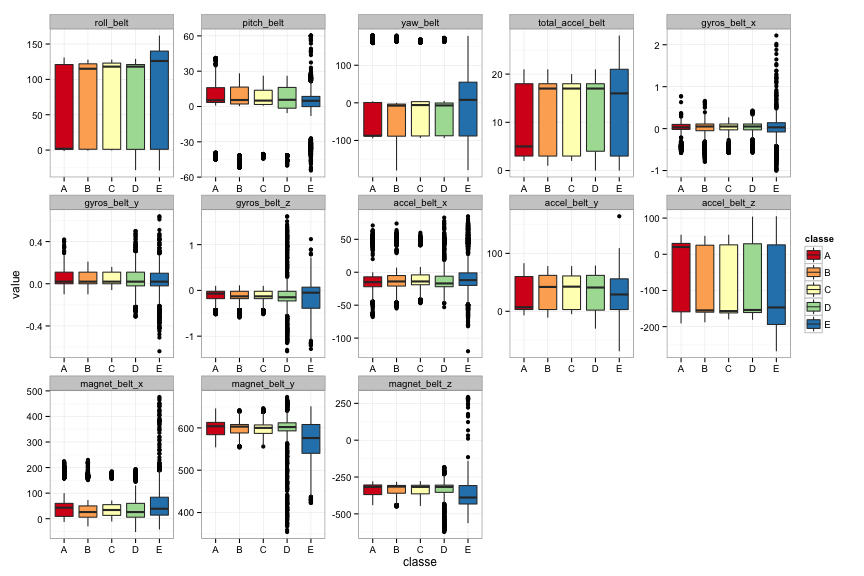

```r
inspect("belt")
```

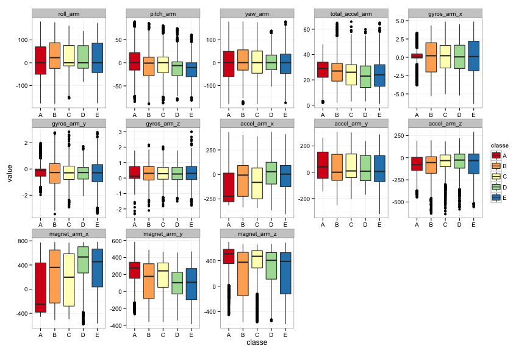

```r
inspect("_arm")
```

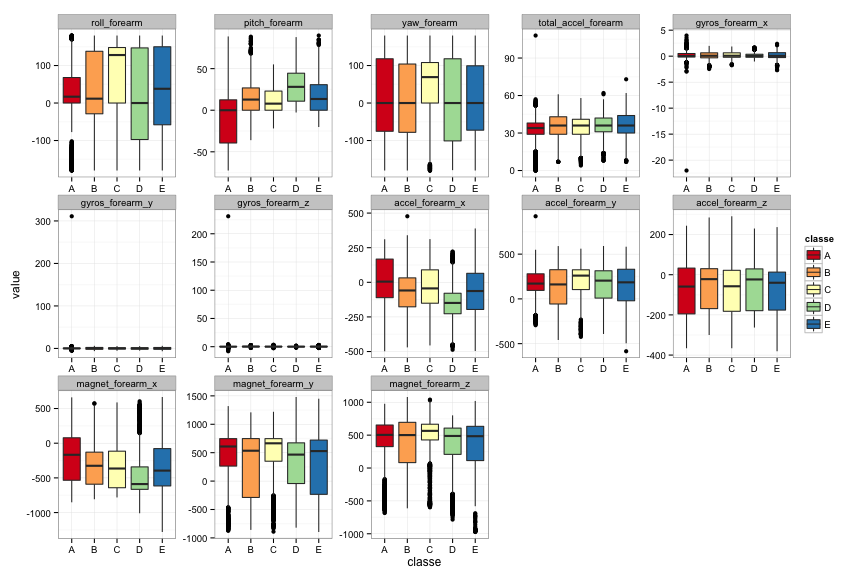

```r
inspect("forearm")
```

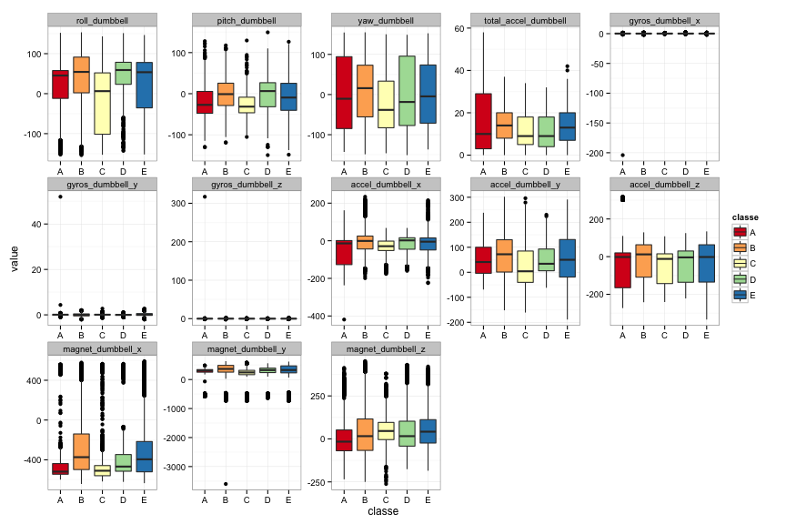

```r
inspect("dumbbell")
```

We can observe that distributions of all the signals in the dataset differ more or less noticeably between the exercise types. However, even though `classe` level `A` (corresponding to correct exercise manner) is often significantly different from the other types, it is usually harder to differentiate between the remaining 4 levels (corresponding to various mistakes).

Additionally there are extreme outliers in some of the variables, the nature of which cannot be identified given the data that we have.

We can thus conclude, that while most signals contain important informatin about the exercise manner, each of them is a weak predictor on its own. It does not appear possible to manually select a few variables for prediction, and therefor in order to reduce the number of predictors it may be beneficial to use **PCA**.